# Carrefour-Marketing-Project Applying Anomaly Detection

Dynasty

2022-07-29

# **Introduction**

Carrefour has 13 outlets mostly located in the suburbs of Kenya’s capital city, Nairobi. Their mission is to provide our customers with quality services, products and food accessible to all across all distribution channels.

## **Problem Statement**

The project aim to inform the marketing department on the most relevant marketing strategies that will result in the highest no. of sales (total price including tax).

## **Metric of Success**

1. Identification of anomalies In the given data set.
2. Provide insights from the analysis on whether there was fraud or not.

## **Anomaly Detection**

Loading libraries

```r
library(tidyverse)
library(anomalize)
library(tibbletime)
library(anomalize)
library(timetk)
```

Loading the data set

```r
data <- read.csv('http://bit.ly/CarreFourSalesDataset')
head(data)
```

```
##        Date    Sales
## 1  1/5/2019 548.9715
## 2  3/8/2019  80.2200
## 3  3/3/2019 340.5255
## 4 1/27/2019 489.0480
## 5  2/8/2019 634.3785
## 6 3/25/2019 627.6165
```

Change Date column to Date format

```r
data$Date <- as.Date(data$Date, format ="%m/%d/%Y")
data$Date <- sort(data$Date, decreasing = FALSE)
```

Will Convert data to a tibble

```r
data <- as_tbl_time(data, index = Date)
head(data)
```

```
## # A time tibble: 6 × 2
## # Index: Date
##   Date       Sales
##   <date>     <dbl>
## 1 2019-01-01 549.
## 2 2019-01-01  80.2
## 3 2019-01-01 341.
## 4 2019-01-01 489.
## 5 2019-01-01 634.
## 6 2019-01-01 628.
```

```r
data <- data %>%
    as_period("daily")
```

Previewing the number of objects in the data set

```r
dim(data)
```

```
## [1] 89  2
```

We have 89 rows and 2 columns

**Visualize the Anomalies**

Plotting Anomalies using different alphas a. alpha 0.5

```
## frequency = 7 days
```

```
## trend = 30 days
```

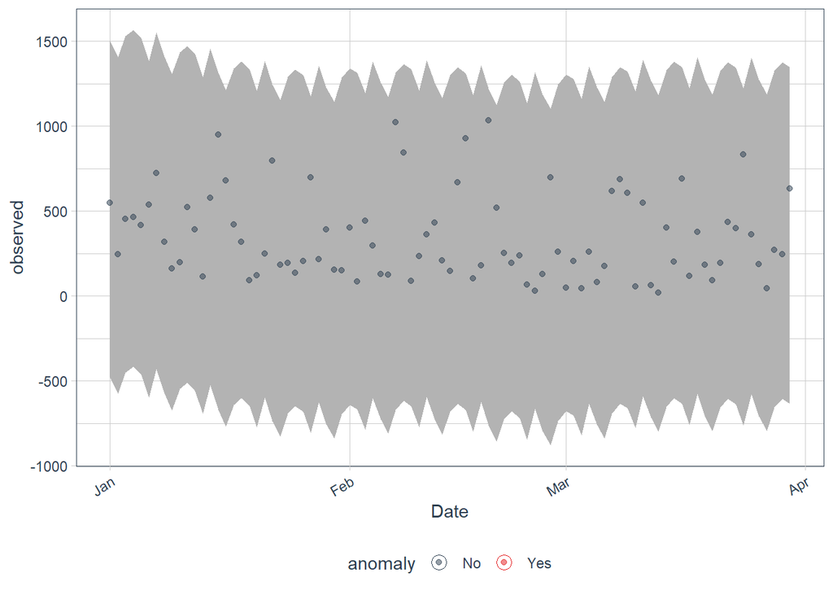

```r
data %>%
    time_decompose(Sales) %>%
    anomalize(remainder) %>%
    time_recompose() %>%
    plot_anomalies(time_recomposed = TRUE, ncol = 3, alpha_dots = 0.5)
```

We can see there was no anomalies (red dot) detected

```
## frequency = 7 days
```

```
## trend = 30 days
```

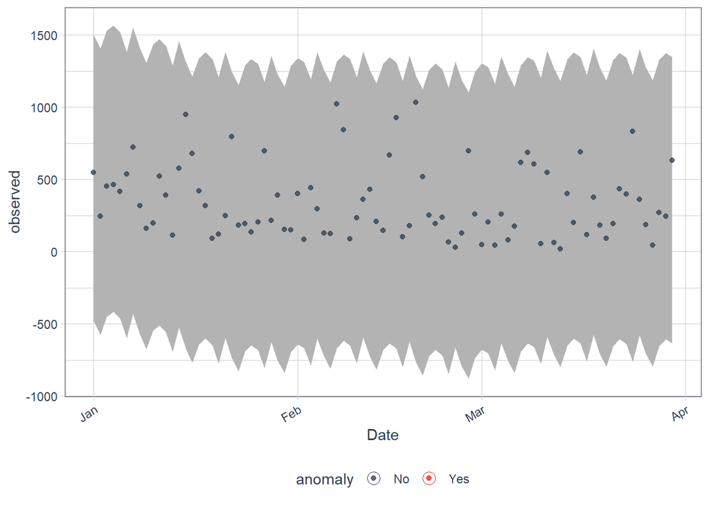

```r
data %>%
    time_decompose(Sales) %>%
    anomalize(remainder) %>%
    time_recompose() %>%
    plot_anomalies(time_recomposed = TRUE, ncol = 3, alpha_dots = 0.75)
```

We can see there was no anomalies (red dot) detected

```
## frequency = 7 days
```

```
## trend = 30 days
```

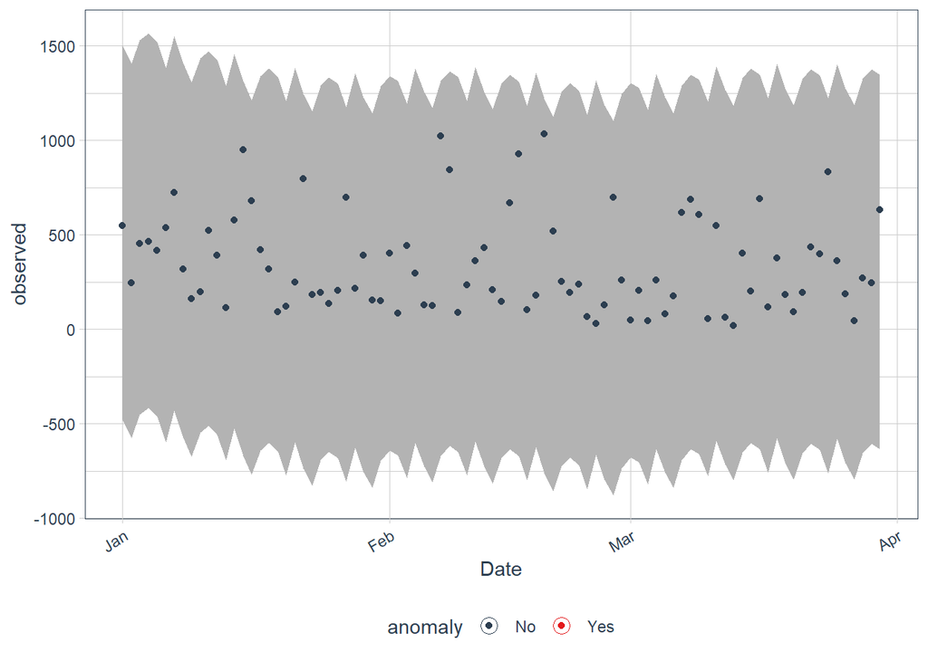

```r
data %>%
    time_decompose(Sales) %>%
    anomalize(remainder) %>%
    time_recompose() %>%
    plot_anomalies(time_recomposed = TRUE, ncol = 3, alpha_dots = 1)
```

We can see there was no anomalies (red dot) detected

```
## frequency = 7 days
```

```
## trend = 30 days
```

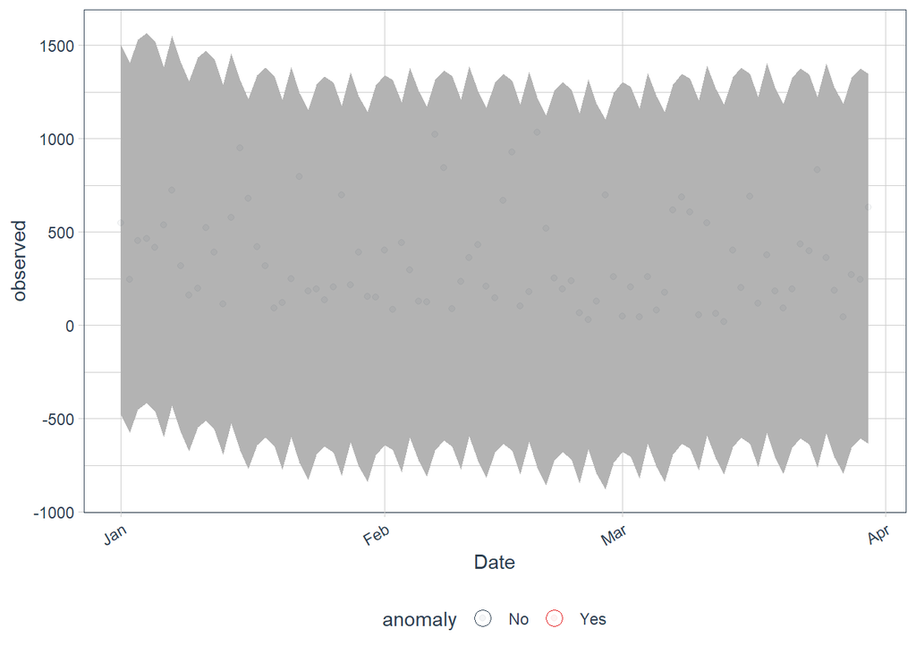

```r
data %>%
    time_decompose(Sales) %>%
    anomalize(remainder) %>%
    time_recompose() %>%
    plot_anomalies(time_recomposed = TRUE, ncol = 3, alpha_dots = 0.05)
```

We can see there was no anomalies (red dot) detected

**Adjusting Trend and Seasonality**

```
## frequency = 7 days
```

```
## trend = 30 days
```

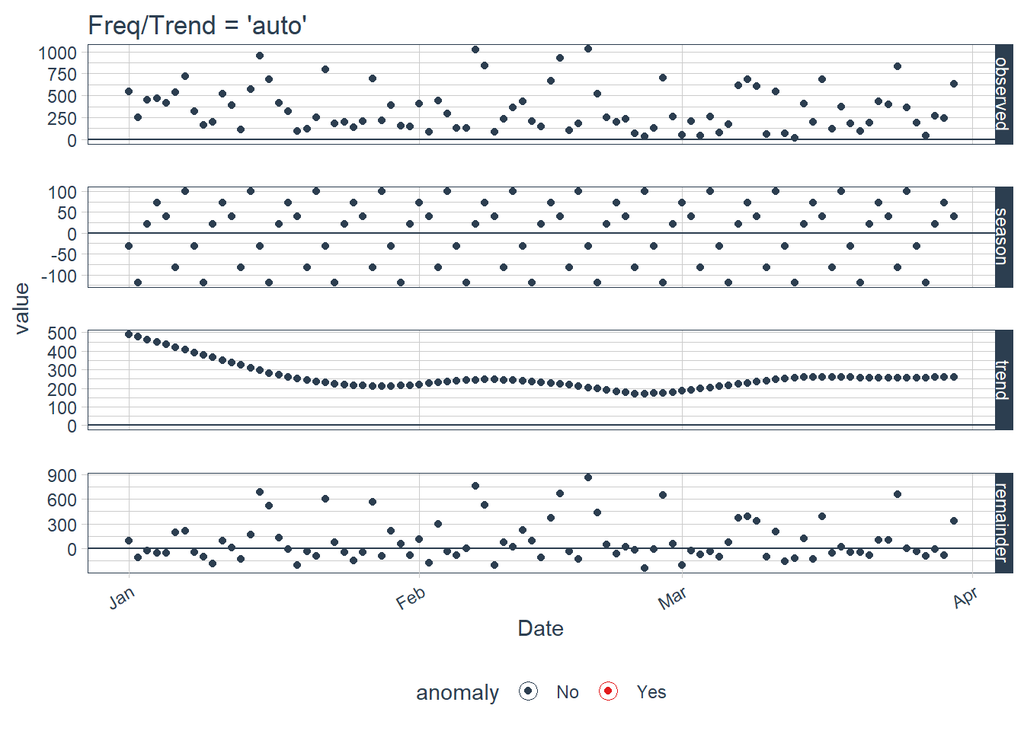

```r
data %>%
    time_decompose(Sales) %>%
    anomalize(remainder) %>%
    time_recompose() %>%
    plot_anomaly_decomposition() +
    ggtitle("Freq/Trend = 'auto'")
```

We still have no anomalies detected.

Let’s view logical frequency and trend spans based on the scale of the data.

```r
get_time_scale_template()
```

```
## # A tibble: 8 × 3
##   time_scale frequency trend
##   <chr>      <chr>     <chr>
## 1 second     1 hour    12 hours
## 2 minute     1 day     14 days
## 3 hour       1 day     1 month
## 4 day        1 week    3 months
## 5 week       1 quarter 1 year
## 6 month      1 year    5 years
## 7 quarter    1 year    10 years
## 8 year       5 years   30 years
```

**Conclusion**

We can confidently advise Carrefour marketing department that there was no anomaly detected.